# Isolinien und Gradienten

**Manfred Brill, Hochschule Kaiserslautern**

Wir haben in der Vorlesung festgehalten, dass der Gradient orthogonal auf der Isolinie eines skalaren Felds ist. Dies werden wir mit Hilfe eines Beispiels mit einigen grafischen Darstellungen vertiefen.

Wir verwenden die quadratische Form $f(x, y) = x + y^2$ als Beispiel. Dafür implementieren wir eine Funktion *quadric*, der wir die Koeffizienten der quadratischen Form übergeben können. Die Namen der Argumente stimmt mit der Notation aus der Vorlesung überein.

```python
import numpy as np

def quadric(x, y, a=1.0, b=0.0, c=1.0, d=np.array([0, 0])):
    """ Quadratische Form """
    return a*x*x + 2.0*b*x*y + c*y*y + d[0]*x + d[1]*y
```

Wir setzen jetzt die Koeffizienten, die wir an *quadric* übergeben und berechnen die Funktionswerte des skalaren Felds. Als Definitionsbereich legen wir *[xmin, xmax] x [ymin, ymax]* fest. Dort erzeugen wir ein *meshgrid*.

```python
xmin = -5.0
xmax = 2.5
ymin = -2.5
ymax = 2.5

n = 200
x = np.linspace(xmin, xmax, n)
y = np.linspace(ymin, ymax, n)
x, y = np.meshgrid(x, y)

a = 0.0
b = 0.0
c = 1.0
d = np.array([1, 0])
z = quadric(x, y, a, b, c, d)
```

## Konturlinien und Punkte

Für die grafische Ausgabe in diesem Notebook setzen wir Matplotlib ein, da wir die Gradienten mit Hilfe von *arrow* ausgeben möchten. Wir werden auch *quiver* verwenden, dies ginge selbstverständlich auch mit Plotly.

Im ersten Schritt legen wir die Konturwerte C fest für die wir Isolinien ausgeben möchten und übergeben diese Information dann an plt.contour.

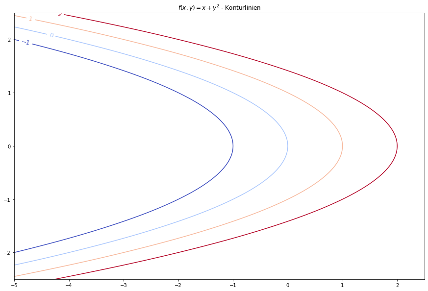

```python
import matplotlib.pyplot as plt
from matplotlib import cm

Cmin = -1.0
Cmax = 2.1
Cstep = 1.0
levels = np.arange(Cmin, Cmax, Cstep)

fig = plt.figure(figsize=(15.0, 10.0))
cplot = plt.contour(x, y, z,
                    levels=levels,
                    origin='lower',
                    cmap=cm.coolwarm,
                    extent=(xmin, xmax, ymin, ymax))

plt.clabel(cplot, inline=1, fontsize=12)
plt.title('$f(x, y) = x + y^2$ - Konturlinien')

plt.show()
```

Wir zeichnen Gradienten für Punkte auf der Isolinie zu C=-1 und C=1 ein. Dazu müssen wir zuerst die Koordinaten solcher Punkte berechnen. Für C=-1 und y=0 können wir die x-Koordinaten eines solchen Punkts berechnen, denn für die x- und y-Koordinaten eines Punkts auf der Isolinie muss ja $f(x, y) = x + y^2$ erfüllt sein.

$x + y^2 = -1 \Leftrightarrow x = -1 - y^2$.

Offensichtlich erhalten wir dann für $y=0$ den Wert $x=-1$. Das führen wir in Python gleich für drei $y$-Werte aus und zeichnen die Punkte ein.

```python
cV = -1.0
gy = np.array([-0.5, 0.0, 0.5])
gx = cV - gy**2
```

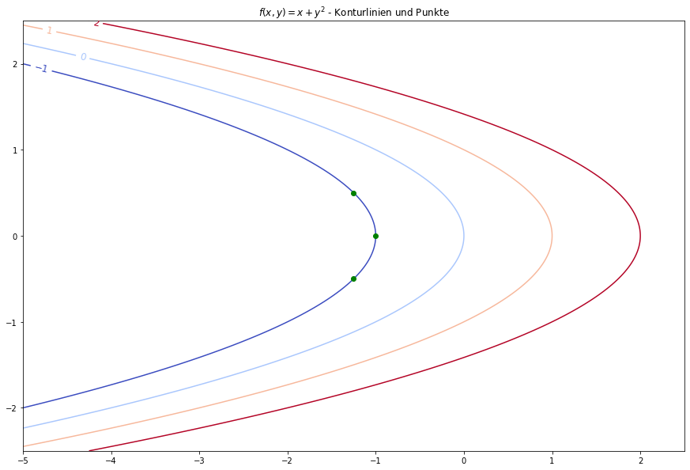

```python
fig = plt.figure(figsize=(15.0, 10.0))
cplot = plt.contour(x, y, z,
                    levels=levels,
                    origin='lower',
                    cmap=cm.coolwarm,
                    extent=(xmin, xmax, ymin, ymax))
plt.plot(gx, gy, 'go')

plt.clabel(cplot, inline=1, fontsize=12)
plt.title('$f(x, y) = x + y^2$ - Konturlinien und Punkte')

plt.show()
```

Wir führen dies auch noch für den Konturwert $C=1$ durch und zeichnen wieder drei Punkt auf dieser Isolinie ein.

```
[]
```

[figure not shown]

```python
fig = plt.figure(figsize=(15.0, 10.0))
cplot = plt.contour(x, y, z,
                    levels=levels,
                    origin='lower',
                    cmap=cm.coolwarm,
                    extent=(xmin, xmax, ymin, ymax))
plt.plot(gx, gy, 'go')

plt.clabel(cplot, inline=1, fontsize=12)
plt.title('$f(x, y) = x + y^2$ - Konturlinien und Punkte')

cV = 1.0
gx = cV - gy**2
plt.plot(gx, gy, 'go')

plt.plot()
```

## Gradienten

Jetzt berechnen wir den Gradienten an jedem dieser sechs Punkte und verwenden die Funktion *arrow* um die Gradienten einzuzeichnen. Der Gradient der quadratischen Form ist eine Linearform. Für den Gradienten erhalten wir

$\nabla f(x, y) = \begin{pmatrix}1\\2y\end{pmatrix}$

Dies fügen wir jetzt der Berechnung der Punktkoordinaten hinzu und geben die Gradienten aus.

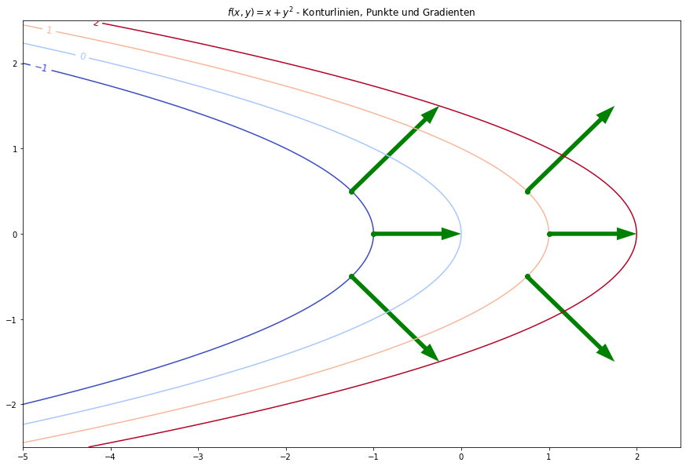

```python
cV = -1.0
gy = np.array([-0.5, 0.0, 0.5])
n = gy.size
gx = cV - gy**2
nablaX = np.ones(shape=(n,))
nablaY = 2.0*gy

fig = plt.figure(figsize=(15.0, 10.0))
cplot = plt.contour(x, y, z,
                    levels=levels,
                    origin='lower',
                    cmap=cm.coolwarm,
                    extent=(xmin, xmax, ymin, ymax))
plt.plot(gx, gy, 'go')

for i in range(0, n):
    plt.arrow(gx[i], gy[i], nablaX[i], nablaY[i],
              width=0.05,
              fc='g',
              ec='none',
              length_includes_head=True,
              lw=0.5)

plt.clabel(cplot, inline=1, fontsize=12)
plt.title('$f(x, y) = x + y^2$ - Konturlinien, Punkte und Gradienten')

cV = 1.0
gx = cV - gy**2
nablaY = 2.0*gy

plt.plot(gx, gy, 'go')
for i in range(0, n):
    plt.arrow(gx[i], gy[i], nablaX[i], nablaY[i],
              width=0.05,
              fc='g',
              ec='none',
              length_includes_head=True,
              lw=0.5)

plt.show()
```

Wir erkennen gut, dass wie in der Vorlesung festgehalten die Gradienten senkrecht auf den Isolinien stehen. Die Vektoren stellen die maximale Aufstiegsrichtung dar.

## Ausgabe mit quiver

Es macht Sinn statt *arrow* in einer Schleife die Funktion *quiver* einzusetzen.

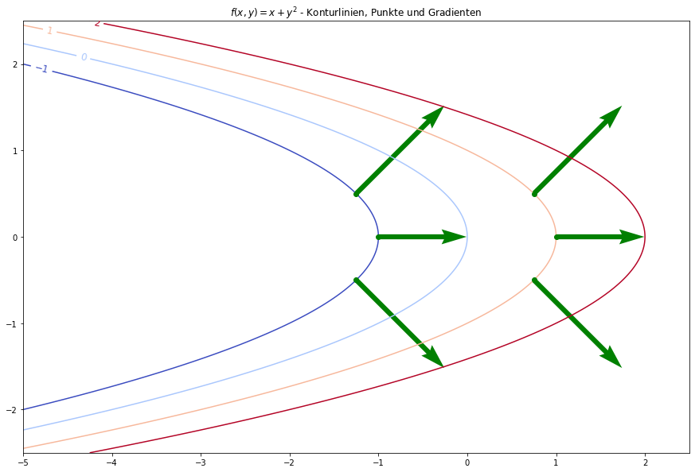

```python
cV = -1.0
gy = np.array([-0.5, 0.0, 0.5])
n = gy.size
gx = cV - gy**2
nablaX = np.ones(shape=(n,))
nablaY = 2.0*gy

fig = plt.figure(figsize=(15.0, 10.0))
cplot = plt.contour(x, y, z,
                    levels=levels,
                    origin='lower',
                    cmap=cm.coolwarm,
                    extent=(xmin, xmax, ymin, ymax))
plt.plot(gx, gy, 'go')

plt.quiver(gx, gy, nablaX, nablaY,
           color='g',
           linewidth=0.25,
           scale=1,
           units='xy')

plt.clabel(cplot, inline=1, fontsize=12)
plt.title('$f(x, y) = x + y^2$ - Konturlinien, Punkte und Gradienten')

cV = 1.0
gx = cV - gy**2
nablaY = 2.0*gy

plt.plot(gx, gy, 'go')
plt.quiver(gx, gy, nablaX, nablaY,
           color='g',
           linewidth=0.25,
           scale=1,
           units='xy')
```